# Project Business Statistics: E-news Express

**Marks: 60**

## Define Problem Statement and Objectives

#### Problem Statement

An online news portal aims to expand its business by acquiring new subscribers. Every visitor to the website takes certain actions based on their interest. The company plans to analyze these interests and wants to determine whether a new feature will be effective or not. Companies often analyze users' responses to two variants of a product to decide which of the two variants is more effective. This experimental technique is known as a/b testing that is used to determine whether a new feature attracts users based on a chosen metric.

Suppose you are hired as a Data Scientist in E-news Express. The design team of the company has created a new landing page. You have been assigned the task to decide whether the new landing page is more effective to gather new subscribers. Suppose you randomly selected 100 users and divided them equally into two groups. The old landing page is served to the first group (control group) and the new landing page is served to the second group (treatment group). Various data about the customers in both groups are collected in 'abtest.csv'. Perform the statistical analysis to answer the following questions using the collected data.

#### Objectives:

1. Explore the dataset and extract insights using Exploratory Data Analysis.
2. Do the users spend more time on the new landing page than the old landing page?
3. Is the conversion rate (the proportion of users who visit the landing page and get converted) for the new page greater than the conversion rate for the old page?
4. Does the converted status depend on the preferred language? [Hint: Create a contingency table using the pandas.crosstab() function]
5. Is the mean time spent on the new page same for the different language users?

*Consider a significance level of 0.05 for all tests.

#### Data Dictionary:

1. user_id - This represents the user ID of the person visiting the website.
2. group - This represents whether the user belongs to the first group (control) or the second group (treatment).
3. landing_page - This represents whether the landing page is new or old.
4. time_spent_on_the_page - This represents the time (in minutes) spent by the user on the landing page.
5. converted - This represents whether the user gets converted to a subscriber of the news portal or not.
6. language_preferred - This represents the language chosen by the user to view the landing page.

## Import all the necessary libraries

```python
import numpy as np
import pandas as pd
from matplotlib import pyplot as plt
import seaborn as sns
import scipy.stats as stats
```

## 1. Explore the dataset and extract insights using Exploratory Data Analysis. (10 Marks)

### Exploratory Data Analysis - Step by step approach

Typical Data exploration activity consists of the following steps:

1. Importing Data
2. Variable Identification
3. Variable Transformation/Feature Creation
4. Missing value detection
5. Univariate Analysis
6. Bivariate Analysis

### Reading the Data into a DataFrame

```python
# write the code for reading the dataset abtest.csv
df=pd.read_csv('abtest.csv')
```

### Data Overview

- View a few rows of the data frame.
- Check the shape and data types of the data frame. Add observations.
- Fix the data-types (if needed).
- Missing Value Check.
- Summary statistics from the data frame. Add observations.

```python
#To view the first few rows of the dataset
df.head()
```

|  | user_id | group | landing_page | time_spent_on_the_page | converted | language_preferred |
| --- | --- | --- | --- | --- | --- | --- |
| 0 | 546592 | control | old | 3.48 | no | Spanish |
| 1 | 546468 | treatment | new | 7.13 | yes | English |
| 2 | 546462 | treatment | new | 4.40 | no | Spanish |
| 3 | 546567 | control | old | 3.02 | no | French |
| 4 | 546459 | treatment | new | 4.75 | yes | Spanish |

```python
#Code to check the shape, that is, the number of rows and columns in the dataset
df.shape
```

```
(100, 6)
```

#### Observation:

There are 100 rows and 6 columns in this dataset

```python
#The following code gives information concerning the data types and memory usage of the dataset
df.info()
```

```
<class 'pandas.core.frame.DataFrame'>
RangeIndex: 100 entries, 0 to 99
Data columns (total 6 columns):
 #   Column                  Non-Null Count  Dtype
---  ------                  --------------  -----
 0   user_id                 100 non-null    int64
 1   group                   100 non-null    object
 2   landing_page            100 non-null    object
 3   time_spent_on_the_page  100 non-null    float64
 4   converted               100 non-null    object
 5   language_preferred      100 non-null    object
dtypes: float64(1), int64(1), object(4)
memory usage: 4.8+ KB
```

#### Observations:

```python
# To change user_id from integer to a string data type since it serves only as a form of identification
df = df.astype({"user_id":'str'})
df.info()
```

```
<class 'pandas.core.frame.DataFrame'>
RangeIndex: 100 entries, 0 to 99
Data columns (total 6 columns):
 #   Column                  Non-Null Count  Dtype
---  ------                  --------------  -----
 0   user_id                 100 non-null    object
 1   group                   100 non-null    object
 2   landing_page            100 non-null    object
 3   time_spent_on_the_page  100 non-null    float64
 4   converted               100 non-null    object
 5   language_preferred      100 non-null    object
dtypes: float64(1), object(5)
memory usage: 4.8+ KB
```

#### Observation:

The user_id column has now been converted to string/object data type

```python
#To check if there is any missing data, the following code is used
df.isnull().sum()
```

```
user_id                   0
group                     0
landing_page              0
time_spent_on_the_page    0
converted                 0
language_preferred        0
dtype: int64
```

#### Observation:

There are no missing values in the dataset

```python
#For a statistical summary of the dataset,the code below is used
df.describe()
```

|  | time_spent_on_the_page |
| --- | --- |
| count | 100.000000 |
| mean | 5.377800 |
| std | 2.378166 |
| min | 0.190000 |
| 25% | 3.880000 |
| 50% | 5.415000 |
| 75% | 7.022500 |
| max | 10.710000 |

#### Observations:

1. There are 100 counts/ observations which is consistent with the number of rows.
2. Mean time spent on the page is 5.3778 minutes which is similar to the 50th centile (5.4150 min)
3. Minimum time spent on the page is 0.19 minutes.
4. Maximum time spent on the page is 10.71 minutes.
5. The standard deviation of this dataset is 2.378166 minutes. However, this applies to the combination of the two groups.

### Univariate Analysis

```python
# function to plot a boxplot and a histogram along the same scale.


def histogram_boxplot(data, feature, figsize=(12, 7), kde=False, bins=None):
    """
    Boxplot and histogram combined

    data: dataframe
    feature: dataframe column
    figsize: size of figure (default (12,7))
    kde: whether to show the density curve (default False)
    bins: number of bins for histogram (default None)
    """
    f2, (ax_box2, ax_hist2) = plt.subplots(
        nrows=2,  # Number of rows of the subplot grid= 2
        sharex=True,  # x-axis will be shared among all subplots
        gridspec_kw={"height_ratios": (0.25, 0.75)},
        figsize=figsize,
    )  # creating the 2 subplots
    sns.boxplot(
        data=data, x=feature, ax=ax_box2, showmeans=True, color="violet"
    )  # boxplot will be created and a star will indicate the mean value of the column
    sns.histplot(
        data=data, x=feature, kde=kde, ax=ax_hist2, bins=bins, palette="winter"
    ) if bins else sns.histplot(
        data=data, x=feature, kde=kde, ax=ax_hist2
    )  # For histogram
    ax_hist2.axvline(
        data[feature].mean(), color="green", linestyle="--"
    )  # Add mean to the histogram
    ax_hist2.axvline(
        data[feature].median(), color="black", linestyle="-"
    )  # Add median to the histogram
```

```python
# function to create labeled barplots


def labeled_barplot(data, feature, perc=False, n=None):
    """
    Barplot with percentage at the top

    data: dataframe
    feature: dataframe column
    perc: whether to display percentages instead of count (default is False)
    n: displays the top n category levels (default is None, i.e., display all levels)
    """

    total = len(data[feature])  # length of the column
    count = data[feature].nunique()
    if n is None:
        plt.figure(figsize=(count + 1, 5))
    else:
        plt.figure(figsize=(n + 1, 5))

    plt.xticks(rotation=45, fontsize=15)
    ax = sns.countplot(data=data, x=feature, palette="Paired", order=data[feature].value_counts().index[:n].sort_values())

    for p in ax.patches:
        if perc == True:
            label = "{:.1f}%".format(100 * p.get_height() / total)  # percentage of each class of the category
        else:
            label = p.get_height()  # count of each level of the category

        x = p.get_x() + p.get_width() / 2  # width of the plot
        y = p.get_height()      # height of the plot

        ax.annotate(label, (x, y), ha="center", va="center", size=12, xytext=(0, 5), textcoords="offset points")  # annotate the percentage

    plt.show()  # show the plot
```

## 1. USER_ID

```python
df['user_id'].nunique() #To check how many unique observations are recoreded in this column
```

```
100
```

#### Observation

Each of the 100 individuals in this dataset was assigned a unique User ID number

## 2. GROUP

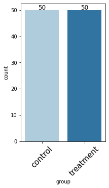

```python
labeled_barplot(df, 'group')
```

#### Observations

1. The group of 100 individuals were evenly split into two groups.
2. The 'control' group received the old landing page.
3. The 'treatment' group received the new landing page.

## 3. LANDING PAGE

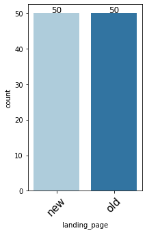

```python
labeled_barplot(df, 'landing_page')
```

#### Observation:

1. The two different landing pages were evenly distributed to the two groups.
2. 50 individuals were made to try the old landing page.
3. 50 individuals were made to try the new landing page.

## 4. Time spent on the page

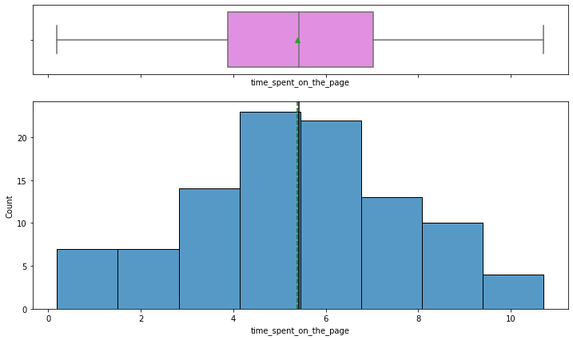

```python
histogram_boxplot(df,'time_spent_on_the_page')
```

#### Observations:

1. Data appears normally distributed.
2. The mean, mode and median are approximately located at the same point between 5 and 6 minutes(5.4 min).
3. Minimum time spent is just above 0 (0.19min).
4. Maximum time spent is over 10 minutes (10.71min),

## 5a. CONVERTED (Total)

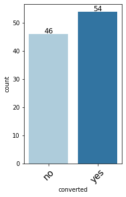

```python
labeled_barplot(df, 'converted')
```

#### Observations:

1. 54% of total individuals were converted into becoming subscribers of their assigned landing pages.
2. 46% of the total were not converted.

## 5b. Converted (Old Landing Page)

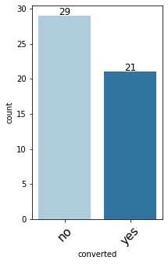

```python
labeled_barplot(df[df['landing_page']=='old'], 'converted')
```

#### Observations:

1. Out of the 50 individuals who used the old landing page, 21 were converted into subscribers.
2. 29 members of this group were not converted into subscribers.

## 5c. CONVERTED (New Landing Page)

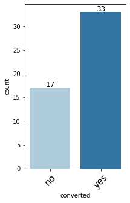

```python
labeled_barplot(df[df['landing_page']=='new'], 'converted')
```

#### Observations:

1. Out of the 50 individuals who used the new landing page, 33 were converted into subscribers.
2. 17 members of this group were not converted into subscribers.

## 6a. PREFERRED LANGUAGE (Both Groups)

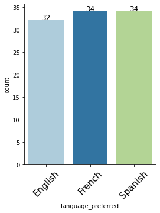

```python
labeled_barplot(df, 'language_preferred')
```

#### Observations:

1. Spanish and French were the most preferred languages. Each was chosen by 34 individuals.
2. 32 individuals chose English as their preferred language.

## 6b. PREFERRED LANGUAGE (Old Landing age)

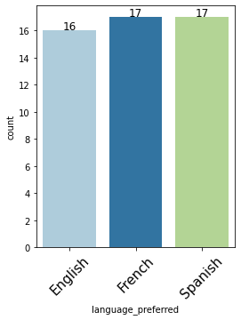

```python
labeled_barplot(df[df['landing_page']=='old'], 'language_preferred')
```

#### Observation:

The distribution of preferred languages for the old landing page is similar that of total distribution. French and Spanish are most preferred.

## 6c. PREFERRED LANGUAGES (New Landing Page)

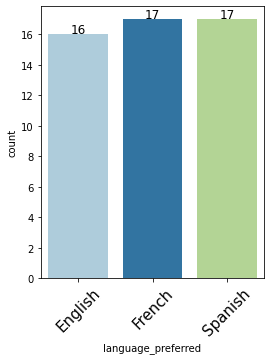

```python
labeled_barplot(df[df['landing_page']=='new'], 'language_preferred')
```

## A) user_id vs time_spent_on_the_page

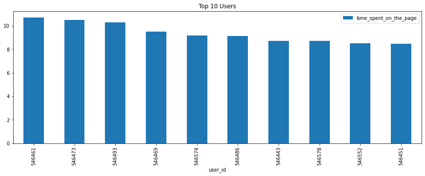

```python
df.groupby(by=['user_id'])['time_spent_on_the_page'].sum().reset_index().sort_values(['time_spent_on_the_page'],
                    ascending=False).head(10).plot(x='user_id',y='time_spent_on_the_page',kind='bar', figsize=(15,5))
plt.title('Top 10 Users')
plt.show()
```

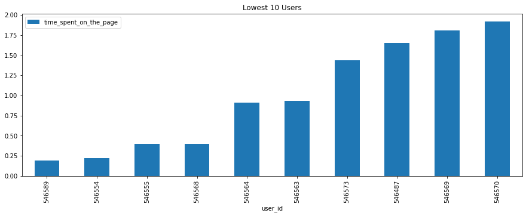

```python
df.groupby(by=['user_id'])['time_spent_on_the_page'].sum().reset_index().sort_values(['time_spent_on_the_page'],
                    ascending=True).head(10).plot(x='user_id',y='time_spent_on_the_page',kind='bar', figsize=(15,5))
plt.title('Lowest 10 Users')
plt.show()
```

#### Observations:

1. User_id 546461 spent the most time on the page.
2. User_id 546589 spent the least time on the page.

## B) Group vs Time_spent_on_the_page

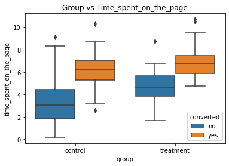

```python
sns.boxplot(data=df, x='group', y='time_spent_on_the_page',hue='converted')
plt.title('Group vs Time_spent_on_the_page')
plt.show()
```

#### Observations:

1. The treatment group (those who tried the new page) spent more time, on average, on their landing page than the control group.
2. Those who converted in each group spent more time on their pages

## C) Landing page vs Time spent on the page

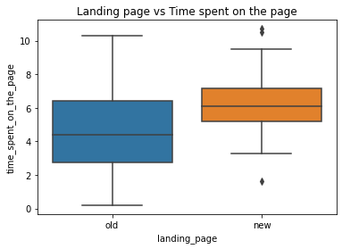

```python
sns.boxplot(data=df, x='landing_page', y='time_spent_on_the_page')
plt.title('Landing page vs Time spent on the page')
plt.show()
```

#### Observation:

More time is spent (on average) on the new page than on the old page.

## D) Use of landing page across languages

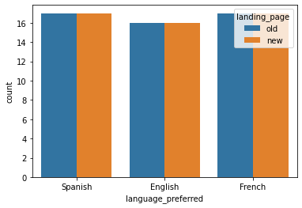

```python
sns.countplot(data=df, x='language_preferred', hue='landing_page')
plt.show()
```

#### Observation

Language preferences are evenly distributed across both groups

## E) Conversion across languages

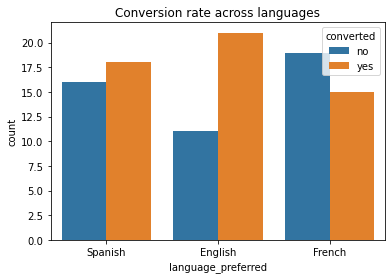

```python
sns.countplot(data=df, x='language_preferred', hue='converted')
plt.title('Conversion rate across languages')
plt.show()
```

#### Observation:

Conversion rate is highest among English users

## F) Time spent on the page vs Preferred Language

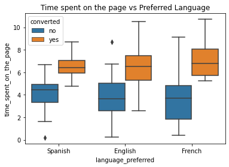

```python
sns.boxplot(data=df, x='language_preferred', y='time_spent_on_the_page', hue='converted')
plt.title('Time spent on the page vs Preferred Language')
plt.show()
```

## 2. Do the users spend more time on the new landing page than the existing landing page? (10 Marks)

### Perform Visual Analysis

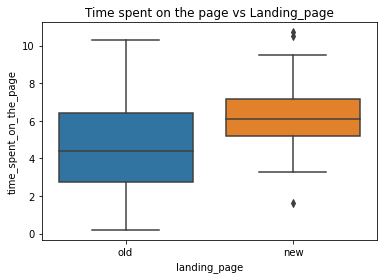

```python
#A boxplot will be used to visualize the numerical variable against the categorical variable
sns.boxplot(data=df, x='landing_page', y='time_spent_on_the_page')
plt.title('Time spent on the page vs Landing_page')
plt.show()
```

#### Observation:

Visual analysis suggests that on average, users spend more time on the new landing page than the existing page.

### Step 1: Define the null and alternate hypotheses

𝐻0: 𝜇1=𝜇2; Users spend an equal amount of time on the existing page and the new page.

### Step 2: Select Appropriate test

The formulated hypotheses concerns the comparison of means of two independent samples consisting of continuous data whose population standard deviations are not known.

Two Independent Sample T-test for Equality of Means will be the most appropriate statistical test for this exercise.

### Step 3: Decide the significance level

As given by the problem statement, α = 0.05

### Step 4: Collect and prepare data

```python
#time spent on existing page
group_1=df[df['landing_page']=='old']['time_spent_on_the_page']

#time spent on new page
group_2=df[df['landing_page']=='new']['time_spent_on_the_page']

print('The mean time for group_1 is ' + str(round(group_1.mean(),2)))
print('The mean time for group_2 is ' + str(round(group_2.mean(),2)))
print('The standard deviation of time for group_1 is ' + str(round(group_1.std(),2)))
print('The standard deviation of time for group_2 is ' + str(round(group_2.std(),2)))
```

```
The mean time for group_1 is 4.53
The mean time for group_2 is 6.22
The standard deviation of time for group_1 is 2.58
The standard deviation of time for group_2 is 1.82
```

These values indicate that the standard deviations of the two samples are unequal which further justifies the use of the independent two sample t-test.

### Step 5: Calculate the p-value

```python
from scipy.stats import ttest_ind

t, p_value = stats.ttest_ind(group_2, group_1, equal_var=False, alternative='greater')
print("The p-value is ", p_value)
```

```
The p-value is  0.0001392381225166549
```

### Step 6: Compare the p-value with $\alpha$

```python
#Conclusion based on p-value
if p_value < 0.05:
    print('As the p-value {p_value} is less than the level of significance, we reject the null hypothesis.')
else:
    print('As the p-value {p_value} is greater than the level of significance, we fail to reject the null hypothesis.')
```

[output not shown]

### Step 7: Draw inference

Since the p-value is less than the 5% (0.05) significance level, we reject the null hypothesis. Hence, there is enough statistical evidence to say that users spent more time on the new landing page than on the existing page.

**A similar approach can be followed to answer the other questions.**

## 3. Is the conversion rate (the proportion of users who visit the landing page and get converted) for the new page greater than the conversion rate for the old page? (10 Marks)

### Visual Analysis

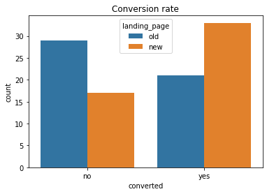

```python
sns.countplot(data=df, x='converted', hue='landing_page')
plt.title ('Conversion rate')
plt.show()
```

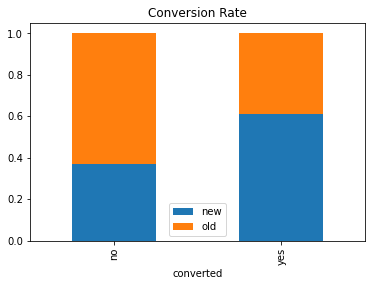

```python
pd.crosstab(df['converted'],df['landing_page'],normalize='index').plot(kind='bar',stacked =True)
plt.title('Conversion Rate')
plt.legend()
plt.show()
```

### Step 1: Define the null and alternate hypotheses

𝐻0: 𝑝1=𝑝2; The proportion of users who get converted on the old page is equal to those who get converted on the new page

### Step 2: Select Appropriate test

The formulated hypotheses involve comparing proportions. A test of proportions should therefore be used in testing the hypotheses. The Two Proportion Z-test is the ideal statistical test for this exercise.

### Step 3: Decide the significance level

As given by the problem statement, α = 0.05

### Step 4: Collect and prepare data

```python
#number of users who converted on the old page
group_1=df[df['landing_page']=='old'].converted.value_counts()['yes']

#number of users who converted on the new page
group_2=df[df['landing_page']=='new'].converted.value_counts()['yes']

print('The numbers of old and new converts are {0} and {1} respectively'.format(group_1, group_2))

# total number of old page users
total_1 =  df.landing_page.value_counts()['old']

# total number of new page users
total_2 =  df.landing_page.value_counts()['new']

print('The total numbers of old page users and new page users are {0} and {1} respectively'.format(total_1, total_2))
```

```
The numbers of old and new converts are 21 and 33 respectively
The total numbers of old page users and new page users are 50 and 50 respectively
```

### Step 5: Calculate the p-value

```python
# find the p-value using proportion_ztest
from statsmodels.stats.proportion import proportions_ztest
stat, pval = proportions_ztest([group_2, group_1] , [total_2, total_1], alternative = 'larger')

# print the p-value
print('The p-value is '+ str(pval))
```

```
The p-value is 0.008026308204056278
```

### Step 6: Compare the p-value with 𝛼

```python
#Conclusion based on p-value
if pval < 0.05:
    print('As the p-value {p_value} is less than the level of significance, we reject the null hypothesis.')
else:
    print('As the p-value {p_value} is greater than the level of significance, we fail to reject the null hypothesis.')
```

[output not shown]

### Step 7: Draw inference

Since the p-value is less than the 5% (0.05) significance level, we reject the null hypothesis. Hence, there is enough statistical evidence to say that the proportion of users who converted on the new landing page are more than the proportion of those who converted on the old page

## 4. Is the conversion and preferred language are independent or related? (10 Marks)

### Visual Analysis

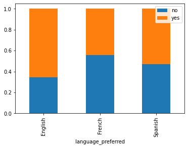

```python
# create a stacked bar plot to compare the distributions of both the categorical features
pd.crosstab(df['language_preferred'],df['converted'],normalize='index').plot(kind='bar',stacked =True)
plt.legend()
plt.show()
```

### Step 1: Define the null and alternate hypotheses

𝐻0: Conversion is independent of preferred language

𝐻𝑎: Conversion is NOT independent of preferred language

### Step 2: Select Appropriate test

The formulated hypotheses concerns comparison of the two categorical variables (conversion and preferred language).

The Chi-square test of independence can be used to test the hypotheses.

### Step 3: Decide the significance level

As given by the problem statement, α = 0.05

### Step 4: Collect and prepare data

```python
# create the contingency table showing the distribution of the two categorical variables
contingency_table = pd.crosstab(df['converted'],df['language_preferred'])
contingency_table
```

| language_preferred converted | English | French | Spanish |
| --- | --- | --- | --- |
| no | 11 | 19 | 16 |
| yes | 21 | 15 | 18 |

### Step 5: Calculate the p-value

```python
# use chi2_contingency() to find the p-value
from scipy.stats import chi2_contingency
chi2, p_value, dof, exp_freq = chi2_contingency(contingency_table)
# print the p-value
print('The p-value is', p_value)
```

```
The p-value is 0.21298887487543447
```

### Step 6: Compare the p-value with 𝛼

```python
#Conclusion based on p-value
if p_value < 0.05:
    print('As the p-value {p_value} is less than the level of significance, we reject the null hypothesis.')
else:
    print('As the p-value {p_value} is greater than the level of significance, we fail to reject the null hypothesis.')
```

[output not shown]

### Step 7: Draw inference

Since the p-value is greater than the level of significance (0.05), we fail to reject the null hypothesis.

There is not enough statistical evidence to say that conversion and preferred language are related.

## 5. Is the time spent on the new page same for the different language users? (10 Marks)

### Visual Analysis

```
language_preferred
English    6.663750
French     6.196471
Spanish    5.835294
Name: time_spent_on_the_page, dtype: float64
```

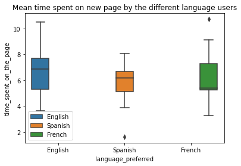

```python
# mean of time spent by different language users on the new page
df1=df[df['landing_page']=='new']
print(df1.groupby("language_preferred")["time_spent_on_the_page"].mean())

# boxplot for visualization
figsize=(6,6)
sns.boxplot(x= "language_preferred", y = 'time_spent_on_the_page' , data = df1, hue = 'language_preferred')
plt.title("Mean time spent on new page by the different language users")
plt.legend(loc='lower left')
plt.show()
```

### Step 1: Define the null and alternate hypotheses

𝐻0 :𝜇1=𝜇2=𝜇3; The mean time spent on the new page is equal across different languages.

𝐻𝑎 : The mean time of at least one of the three languages is different.

### Step 2: Select Appropriate test

The hypotheses concerns three population means (time spent on the new page by THREE user languages).

One-way ANOVA could be the appropriate test here provided normality and equality of variance assumptions are verified.

1. To test normality, Shapiro-Wilk’s test is applied to the response variable.
2. To test for equality of variance, Levene test is applied to the response variable.

#### Shapiro-Wilk’s test

𝐻0: The time spent on the mew landing page follows a normal distribution

𝐻𝑎: The time spent on the new landing page does not not follow a normal distribution

```python
# Assumption 1: Normality
# import the required function
from scipy import stats

# find the p-value
w, p_value = stats.shapiro(df1['time_spent_on_the_page'])
print('The p-value is', p_value)
```

```
The p-value is 0.8040016293525696
```

Since p-value of the test is larger than the 5% (0.05) significance level, we fail to reject the null hypothesis that the response variable (time spent on the page) follows the normal distribution.

#### Levene’s test

𝐻0 : All the population variances are equal

𝐻𝑎 : At least one variance is different from the rest

```python
#Assumption 2: Homogeneity of Variance

# find the p-value using the levene function from stats
statistic, p_value = stats.levene(df1[df1['language_preferred']=='English']['time_spent_on_the_page'],
                            df1[df1['language_preferred']=='Spanish']['time_spent_on_the_page'],
                            df1[df1['language_preferred']=='French']['time_spent_on_the_page'])
print('The p-value is', p_value)
```

```
The p-value is 0.46711357711340173
```

Since the p-value is larger than the 5% (0.05) significance level, we fail to reject the null hypothesis of homogeneity of variances.

### Step 3: Decide the significance level

As given by the problem statement, α = 0.05

### Step 4: Collect and prepare data

```python
# separate the time spent on the new page with respect to the three languages
df1=df[df['landing_page']=='new']
group_1 = df1[df1['language_preferred']=='English']['time_spent_on_the_page']
group_2 = df1[df1['language_preferred']=='French']['time_spent_on_the_page']
group_3 = df1[df1['language_preferred']=='Spanish']['time_spent_on_the_page']
```

### Step 5: Calculate the p-value

```python
# perform one-way anova test using the f_oneway function
from scipy.stats import f_oneway
test_stat, p_value = f_oneway(group_1, group_2, group_3)
print('The p-value is ', p_value)
```

```
The p-value is  0.43204138694325955
```

### Step 6: Compare the p-value with 𝛼

```python
if p_value < 0.05:
    print(f'As the p-value {p_value} is less than the level of significance, we reject the null hypothesis.')
else:
    print(f'As the p-value {p_value} is greater than the level of significance, we fail to reject the null hypothesis.')
```

```
As the p-value 0.43204138694325955 is greater than the level of significance, we fail to reject the null hypothesis.
```

### Step 7: Draw inference

Since the p-value is greater than the level of significance (0.05), we fail to reject the null hypothesis.

There is not enough statistical evidence to say that means are not equal.

Any observed difference is likely due to chance.

## Conclusion and Business Recommendations

### Conclusion:

1. Fron the statistical analysis, users spend more time on the new page than on the old.
2. The conversion rate is greater on the new landing page than on the old page.
3. Conversion is not dependent on user language but it is worthy to note that more English users converted in this dataset and further analysis may be needed to explore this phenomenon.
4. There isn't enough evidence to show that the mean time spent on the new page is not the same for the different language users.